# ACL Project

**Analyzing ACL Tear Data to Discover Demographic, Injury, Diagnosis, and Information Trends**

Marisa Ricci and Matthew Scherp

Hyperlink to github webpage: https://matthewbubble.github.io/

**Project Description**

Our project is an analysis of data relating to ACL tears. Both of us play soccer and ACL tears are both incredibly common and take a very long time to recover from so we wanted to do an analyis to find correlations between different variables and ACL tears. If people are more aware of the causes of ACL tears they can prevent and diagnose them better. Additionally, to definitively diagnose an ACL tear, arthroscopy must be used. However, this is a surgery and if the tear was initially misdiagnosed this procudedure would be done for no reason (the goal is to repair the tear). If we could build a model to more accurately predict the likelihood of a tear noninvasively, this expensive procedure could be bypassed except in cases where it is necessary for the ACL repair.

**Collaboration Plan**

We are in every class together and also work the same on campus job. Currently, we plan to meet on each other's shifts, for at least 2-3 hours a week, but up to 8 if needed. We have set up our GitHub repository to share information and are sharing a Colab notebook to update coding for our dataset. We also each have copies of the Colab notebooks and can commit the changes to the master which reduces the possibility of changes getting overwritten if we are working at the same time. We also have each picked a data set to be the "expert" in and as we had more data sets we will likely continue to specialize. However, we are checking in with each other and giving the other person suggestions for other interesting elements to work on in their data.

**Project Goals**

By the end of this project we want to have found statistical relationships in our ACL data relating to diagnosis, demographics, and injury mechanism. While we can't draw any causation related conclusions from statistical correlations, we can see potential avenues for further research.

**Final Question**

What are the factors that affect a person's likelihood to tear their ACL and how can it be diagnosed the easiest?

**DATA SETS/WORKS CITED**

Schmidt, Gregory (2021). Raw ACL Data.xlsx. figshare. Dataset. https://doi.org/10.6084/m9.figshare.16620421.v1

Nagano, Yasuharu (2017). raw_data.csv. Dataset. https://zenodo.org/records/844853

Ziya (2024). Basketball.csv. Dataset. https://www.kaggle.com/datasets/ziya07/basketball-player-injury-in-sports-rehabilitation

```python
import pandas as pd
import numpy as np
import matplotlib.pyplot as plt
import string as str
import seaborn as sns
from sklearn.model_selection import cross_val_predict
from sklearn.metrics import confusion_matrix
from sklearn.model_selection import cross_val_score
from sklearn.preprocessing import LabelEncoder
from sklearn.neighbors import KNeighborsClassifier
```

```python
from google.colab import drive
drive.mount('/content/drive')
%cd /content/drive/MyDrive/'Colab Notebooks'
```

```
/content/drive/MyDrive/Colab Notebooks
```

# **Data Collection (Datasets)**

This first dataset (labeled "ACL2"), includes a lot of relevant information regarding the patients and their injuries, such as previous surgeries, the cause of injury, age, sex, knee, and severity of the injury. With this dataset, we hope to answer some questions about what types of movements and/or sports cause the most ACL tears. For example, do factors outside of exclusive movement create other additional risks to tearing the ACL, or maybe even age and gender?

```python
# import data
ACL2 = pd.read_excel('../Project/RawACLData.xlsx')
# drop blank columns with no data
ACL2 = ACL2.drop(columns=['Unnamed: 0', 'Unnamed: 1','Column1', 'Column2',
                          'Column3', 'Column4', 'Column5', 'Column6', 'Number'])
# drop all rows past 88 (last row with usable data because rows below might
# have 2-5 columns filled out of the 27)
ACL2 = ACL2.reset_index(drop=True)
ACL2 = ACL2.iloc[:88]
# rename columns
ACL2 = ACL2.rename(columns={'injured knee (R or L)': 'Injured Knee',
                            'Lachman injured (pos=1, neg=0)':'Lachman injured',
                            'Diagnosis by Physician (Y=1 or N=0)':'Diagnosis by Physician',
                            'ACL Arthroscopy (1 = torn ACL or 0 = intact ACL)':'ACL Arthroscopy',
                            'Effusion (1 or 0)':'Effusion',
                            'MRI (1 or 0)':'MRI',
                            'ACL MRI (1 = torn ACL or 0 = ACL intact)':'ACL MRI',
                            'OR (1 or 0)':'ACL or Meniscus',
                            'Arthroscopy (1 = completely confirmed MRI or 0 = did not confirm)':'Arthroscopy confirmed MRI',
                            'ACL Arthroscopy (1 = torn ACL or 0 = intact ACL)': 'Torn ACL from Arthroscopy'})
ACL2.head()
```

|  | Age | sex | Injured Knee | Lachman injured | Anterior Drawer injured | Lever injured | Diagnosis by Physician | Lachman unaffected | Anterior Drawer Unaffected | Lever unaffected | ... | Torn ACL from Arthroscopy | ACL Lat Meniscus | ACL Medial | Intraop findings | Scope Lat Men | Scope Med Men | Pivot Shift intraop injured | Previous Knee Surgery | mechanism of injury | Date of Operation for Current Injury |
| --- | --- | --- | --- | --- | --- | --- | --- | --- | --- | --- | --- | --- | --- | --- | --- | --- | --- | --- | --- | --- | --- |
| 0 | 29.0 | F | L | 0.0 | 0.0 | 1 | 0.0 | 0.0 | 0.0 | 1.0 | ... | 1.0 | NaN | NaN | (+) empty wall sign | 0.0 | NaN | Y | No | Fall | 2019-04-26 |
| 1 | 30.0 | M | R | 1.0 | 0.0 | 1 | 1.0 | 0.0 | 0.0 | 1.0 | ... | 1.0 | 0.0 | 1.0 | ACL and LATERAL mensicus | 1.0 | NaN | 1 | NaN | Soccer | NaT |
| 2 | 18.0 | M | L | 1.0 | 0.0 | 0 | 1.0 | 0.0 | 0.0 | 0.0 | ... | 1.0 | NaN | NaN | ACL and medial meniscus tear | 0.0 | 1.0 | NaN | NaN | Tackled with planted foot | 2018-04-04 |
| 3 | 31.0 | M | R | 1.0 | 0.0 | 0 | 1.0 | 0.0 | 0.0 | 0.0 | ... | 1.0 | NaN | NaN | ACL and MEDIAL MENISCUS TEAR | 0.0 | 1.0 | NaN | No | valgus force (basketball) | 2018-11-29 |
| 4 | 28.0 | F | R | 0.0 | 0.0 | 0 | 0.0 | 0.0 | 0.0 | 0.0 | ... | 1.0 | NaN | NaN | ACL tear + lateral meniscus tear | 1.0 | NaN | 1 | Left ACL reconstruction | Planting (Soccer) | 2018-08-31 |

5 rows × 27 columns

```python
ACL2.dtypes
```

|  | 0 |
| --- | --- |
| Age | float64 |
| sex | object |
| Injured Knee | object |
| Lachman injured | float64 |
| Anterior Drawer injured | float64 |
| Lever injured | object |
| Diagnosis by Physician | float64 |
| Lachman unaffected | float64 |
| Anterior Drawer Unaffected | float64 |
| Lever unaffected | float64 |
| Effusion | float64 |
| MRI | float64 |
| ACL MRI | float64 |
| MRI findings | object |
| ACL and Meniscus | float64 |
| ACL or Meniscus | float64 |
| Arthroscopy confirmed MRI | float64 |
| Torn ACL from Arthroscopy | float64 |
| ACL Lat Meniscus | float64 |
| ACL Medial | float64 |
| Intraop findings | object |
| Scope Lat Men | float64 |
| Scope Med Men | float64 |
| Pivot Shift intraop injured | object |
| Previous Knee Surgery | object |
| mechanism of injury | object |
| Date of Operation for Current Injury | datetime64[ns] |

**dtype:** object

ACL3 is a questionnaire dataset that is relevant to the awareness of ACL tears and what people believe are factors causing these tears. We think this will be a good dataset to understand how/where people are finding out about ACL tears and how common and severe it is. While we won't be building our model off of this dataset, we can use it to compare our model to what people believe are factors in ACL tears and see how informed the general public is.

```python
ACL3 = pd.read_csv("../Project/raw_data.csv",encoding = "latin-1")
#Removing first row, and renaming all of the columns into names that are
#recognizable and short for ease of calling
ACL3 = ACL3[1:].astype(int)
ACL3.columns = ["UserID", "ACL", "Self Injury", "Injured Family/Friend","Friends","Family",
                "Coach","Health Class", "Other Class","TV", "Magazine",
                "Comic","Internet", "Newpaper","Poster","Other","Bone Geometry",
                "ACL Size","Joint Laxity","Hormone","Flexibility","Foot Pronation",
                "Weak Quadricep Muscle", "Weak Hamstring Muscle","Weak Hip Muscle","Balance",
                "Weight","Drinking","Smoking","Genu Valgum","Genu Varum",
                "Sex","Age"]
#Making Male and Female easily read on the dataset
ACL3["Sex"] = ACL3["Sex"].map({
    0:"M",
    1:"F"
})

ACL3.head()
```

|  | UserID | ACL | Self Injury | Injured Family/Friend | Friends | Family | Coach | Health Class | Other Class | TV | ... | Weak Hamstring Muscle | Weak Hip Muscle | Balance | Weight | Drinking | Smoking | Genu Valgum | Genu Varum | Sex | Age |
| --- | --- | --- | --- | --- | --- | --- | --- | --- | --- | --- | --- | --- | --- | --- | --- | --- | --- | --- | --- | --- | --- |
| 1 | 1 | 1 | 0 | 0 | 0 | 0 | 0 | 0 | 0 | 1 | ... | 2 | 2 | 1 | 1 | 2 | 2 | 2 | 2 | NaN | 34 |
| 2 | 2 | 1 | 0 | 0 | 0 | 0 | 0 | 0 | 0 | 1 | ... | 1 | 1 | 1 | 1 | 2 | 2 | 1 | 1 | F | 49 |
| 3 | 3 | 1 | 0 | 0 | 0 | 0 | 0 | 0 | 0 | 1 | ... | 1 | 1 | 1 | 1 | 2 | 2 | 2 | 1 | F | 49 |
| 4 | 4 | 1 | 0 | 0 | 0 | 0 | 0 | 0 | 0 | 1 | ... | 1 | 2 | 1 | 1 | 2 | 2 | 1 | 1 | NaN | 53 |
| 5 | 5 | 1 | 0 | 0 | 0 | 0 | 0 | 0 | 0 | 1 | ... | 1 | 1 | 1 | 1 | 2 | 2 | 1 | 1 | NaN | 52 |

5 rows × 33 columns

```python
ACL3.dtypes
```

|  | 0 |
| --- | --- |
| UserID | int64 |
| ACL | int64 |
| Self Injury | int64 |
| Injured Family/Friend | int64 |
| Friends | int64 |
| Family | int64 |
| Coach | int64 |
| Health Class | int64 |
| Other Class | int64 |
| TV | int64 |
| Magazine | int64 |
| Comic | int64 |
| Internet | int64 |
| Newpaper | int64 |
| Poster | int64 |
| Other | int64 |
| Bone Geometry | int64 |
| ACL Size | int64 |
| Joint Laxity | int64 |
| Hormone | int64 |
| Flexibility | int64 |
| Foot Pronation | int64 |
| Weak Quadricep Muscle | int64 |
| Weak Hamstring Muscle | int64 |
| Weak Hip Muscle | int64 |
| Balance | int64 |
| Weight | int64 |
| Drinking | int64 |
| Smoking | int64 |
| Genu Valgum | int64 |
| Genu Varum | int64 |
| Sex | object |
| Age | int64 |

**dtype:** object

Our third dataset (labeled basketball_df) focuses primarily on basketball related injuries. This dataset was filtered to only focus on ACL related injuries (ACL4). From this dataset we hope to obtain information on demographics such as weight and height and their effect on potential for ACL tears.

```python
basketball_df = pd.read_csv("../Project/Basketball.csv",encoding = "latin-1")
ACL4 = basketball_df[basketball_df["Injury_Type"] == "ACL Tear"]
ACL4
```

|  | Player_ID | Age | Height_cm | Weight_kg | Position | Injury_Type | Injury_Severity | Rehabilitation_Program | Rehabilitation_Time_weeks | Injury_Recurrence | Date_of_Injury | Rehabilitation_Efficiency_Score | knee_angle_deg | jump_height_cm | ankle_flexion_deg | speed_m_s | reaction_time_ms |
| --- | --- | --- | --- | --- | --- | --- | --- | --- | --- | --- | --- | --- | --- | --- | --- | --- | --- |
| 0 | 1 | 24 | 195 | 108 | Center | ACL Tear | Severe | Physiotherapy | 7 | 0 | 2017-12-19 | 0.862860 | 78.327638 | 77.705191 | 37.926663 | 56.578469 | 64.259747 |
| 13 | 14 | 19 | 199 | 95 | Forward | ACL Tear | Moderate | Strength Training | 8 | 1 | 2021-10-23 | 0.984957 | 55.933047 | 34.654739 | 53.344942 | 92.618656 | 94.707734 |
| 17 | 18 | 34 | 184 | 74 | Guard | ACL Tear | Moderate | Flexibility Exercises | 10 | 1 | 2015-10-05 | 0.707410 | 62.377430 | 39.784066 | 54.244220 | 48.807415 | 90.342986 |
| 20 | 21 | 32 | 182 | 78 | Guard | ACL Tear | Severe | Balance Training | 8 | 0 | 2014-04-12 | 0.932361 | 47.670586 | 41.455916 | 61.655256 | 48.052138 | 88.024083 |
| 27 | 28 | 24 | 197 | 102 | Forward | ACL Tear | Severe | Flexibility Exercises | 8 | 0 | 2015-01-20 | 0.924824 | 67.283209 | 57.471158 | 94.039213 | 31.287347 | 53.791247 |
| 33 | 34 | 24 | 194 | 109 | Forward | ACL Tear | Mild | Balance Training | 10 | 0 | 2019-04-10 | 0.614321 | 44.801360 | 82.332657 | 42.462518 | 75.599427 | 52.312675 |
| 39 | 40 | 34 | 172 | 98 | Forward | ACL Tear | Severe | Physiotherapy | 2 | 0 | 2016-01-23 | 0.760154 | 85.241987 | 93.453048 | 65.153651 | 91.172305 | 90.906921 |
| 42 | 43 | 21 | 177 | 71 | Center | ACL Tear | Severe | Balance Training | 7 | 0 | 2016-12-05 | 0.926091 | 67.597458 | 95.788249 | 82.497233 | 76.552567 | 67.025599 |
| 49 | 50 | 27 | 201 | 83 | Center | ACL Tear | Moderate | Balance Training | 8 | 0 | 2016-01-14 | 0.877569 | 75.214207 | 92.572481 | 69.538879 | 41.639836 | 63.591293 |
| 54 | 55 | 25 | 171 | 72 | Center | ACL Tear | Severe | Flexibility Exercises | 8 | 0 | 2021-07-03 | 0.507272 | 46.605875 | 82.076240 | 60.853392 | 57.250693 | 59.243675 |
| 59 | 60 | 32 | 171 | 91 | Forward | ACL Tear | Moderate | Physiotherapy | 4 | 0 | 2018-01-24 | 0.952079 | 43.059692 | 53.945722 | 90.324993 | 69.648325 | 54.823551 |
| 61 | 62 | 26 | 192 | 107 | Guard | ACL Tear | Severe | Physiotherapy | 9 | 0 | 2017-03-31 | 0.756995 | 42.136152 | 37.744222 | 56.131652 | 76.456982 | 50.741568 |
| 62 | 63 | 32 | 206 | 107 | Guard | ACL Tear | Mild | Strength Training | 4 | 0 | 2018-01-18 | 0.891827 | 92.773580 | 89.251660 | 48.952127 | 95.578082 | 46.352543 |
| 63 | 64 | 30 | 201 | 77 | Center | ACL Tear | Moderate | Balance Training | 11 | 0 | 2016-12-31 | 0.698271 | 35.616362 | 38.924206 | 75.079968 | 81.280047 | 32.946523 |
| 70 | 71 | 28 | 175 | 97 | Guard | ACL Tear | Mild | Strength Training | 10 | 0 | 2021-07-23 | 0.629122 | 90.585499 | 74.880334 | 45.538051 | 71.778999 | 96.497283 |
| 71 | 72 | 34 | 201 | 102 | Guard | ACL Tear | Severe | Balance Training | 6 | 0 | 2016-06-15 | 0.729568 | 87.195045 | 78.576391 | 46.175236 | 53.397072 | 85.044151 |
| 72 | 73 | 25 | 173 | 74 | Forward | ACL Tear | Severe | Balance Training | 2 | 0 | 2014-10-14 | 0.990016 | 48.053198 | 67.990711 | 77.032492 | 83.963854 | 36.258770 |
| 79 | 80 | 26 | 175 | 98 | Guard | ACL Tear | Moderate | Physiotherapy | 9 | 0 | 2014-01-19 | 0.564023 | 83.864505 | 62.340406 | 36.960897 | 47.248142 | 99.381804 |
| 87 | 88 | 22 | 198 | 102 | Center | ACL Tear | Severe | Balance Training | 11 | 0 | 2020-10-14 | 0.833779 | 50.204139 | 95.248280 | 50.520341 | 94.211950 | 45.434035 |
| 92 | 93 | 18 | 195 | 72 | Forward | ACL Tear | Severe | Balance Training | 6 | 1 | 2021-06-01 | 0.639295 | 33.627648 | 40.677733 | 31.857254 | 67.933066 | 97.837184 |
| 93 | 94 | 20 | 172 | 87 | Guard | ACL Tear | Mild | Physiotherapy | 2 | 0 | 2021-06-21 | 0.588505 | 53.562299 | 70.340185 | 42.700480 | 91.106209 | 91.865012 |

```python
ACL4.dtypes
```

|  | 0 |
| --- | --- |
| Player_ID | int64 |
| Age | int64 |
| Height_cm | int64 |
| Weight_kg | int64 |
| Position | object |
| Injury_Type | object |
| Injury_Severity | object |
| Rehabilitation_Program | object |
| Rehabilitation_Time_weeks | int64 |
| Injury_Recurrence | int64 |
| Date_of_Injury | object |
| Rehabilitation_Efficiency_Score | float64 |
| knee_angle_deg | float64 |
| jump_height_cm | float64 |
| ankle_flexion_deg | float64 |
| speed_m_s | float64 |
| reaction_time_ms | float64 |

**dtype:** object

# Data Processing, Exploratory Analysis, and Visualization

## Mechanism of Injury

To begin answering our investigation question we started by investigating mechanism of injury using the ACL2 dataset.

Mechanism of injury was likely noted by a doctor and the notes are not consistent (some are more detailed than others). To make more distict categories (although there will still be many), general categories were first combined or standardized. Next specific categories (e.g. soccer, vehicle accident) were allowed to overwrite the more general categories to get a better idea of what actually caused the potential ACL injury. From this data, we were able to generate a graph that showed what geneally causes a potential ACL tear.

[output not shown]

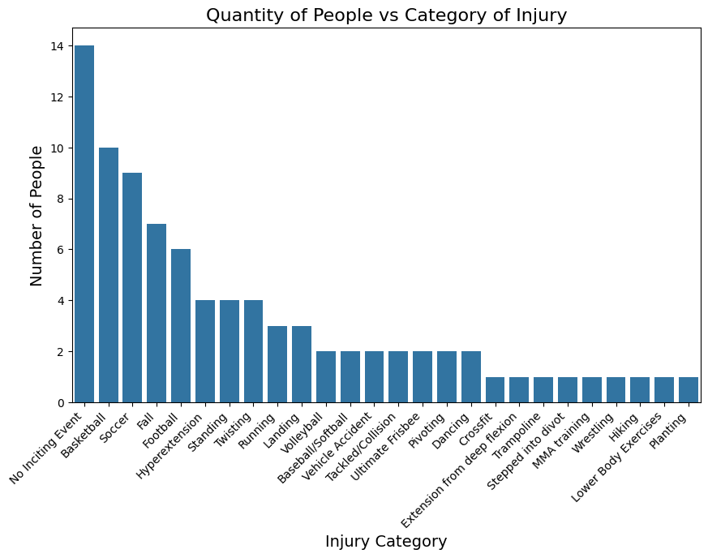

```python
# causes of potential ACL tear
causes_df = ACL2[["mechanism of injury"]]

# new column category based on mechanism of injury
causes_df['category'] = causes_df['mechanism of injury']

# Assign category to rows where the mechanism of injury contains the specific row

# Nothing assigned twice and specific events (e.g. soccer, vehicle accident)
# are preferenced over general motions (e.g. twisting, standing)

# Some things were also not standard such as pivot vs pivoting so those needed
# to be put in one category.

# general categories
causes_df.loc[causes_df['mechanism of injury'].str.contains(
    'Tackled', case=False, na=False), 'category'] = 'Tackled/Collision'
causes_df.loc[causes_df['mechanism of injury'].str.contains(
    'Collision', case=False, na=False), 'category'] = 'Tackled/Collision'
causes_df.loc[causes_df['mechanism of injury'].str.contains(
    'twisting', case=False, na=False), 'category'] = 'Twisting'
causes_df.loc[causes_df['mechanism of injury'].str.contains(
    'Fall', case=False, na=False), 'category'] = 'Fall'
causes_df.loc[causes_df['mechanism of injury'].str.contains(
    'pivot', case=False, na=False), 'category'] = 'Pivoting'
causes_df.loc[causes_df['mechanism of injury'].str.contains(
    'Landing', case=False, na=False), 'category'] = 'Landing'
causes_df.loc[causes_df['mechanism of injury'].str.contains(
    'Standing', case=False, na=False), 'category'] = 'Standing'
causes_df.loc[causes_df['mechanism of injury'].str.contains(
    'Hyperextension', case=False, na=False), 'category'] = 'Hyperextension'
causes_df.loc[causes_df['mechanism of injury'].str.contains(
    'Hypextension', case=False, na=False), 'category'] = 'Hyperextension'
causes_df.loc[causes_df['mechanism of injury'].str.contains(
    'Hyperextended', case=False, na=False), 'category'] = 'Hyperextension'
causes_df.loc[causes_df['mechanism of injury'].str.contains(
    'No inciting event', case=False, na=False), 'category'] = 'No Inciting Event'
causes_df.loc[causes_df['mechanism of injury'].str.contains(
    'Nothing specific', case=False, na=False), 'category'] = 'No Inciting Event'

# more specific categories (will overwrite general categories if specificity found)
causes_df.loc[causes_df['mechanism of injury'].str.contains(
    'Soccer', case=False, na=False), 'category'] = 'Soccer'
causes_df.loc[causes_df['mechanism of injury'].str.contains(
    'Football', case=False, na=False), 'category'] = 'Football'
causes_df.loc[causes_df['mechanism of injury'].str.contains(
    'Footabll', case=False, na=False), 'category'] = 'Football'
causes_df.loc[causes_df['mechanism of injury'].str.contains(
    'Basketball', case=False, na=False), 'category'] = 'Basketball'
causes_df.loc[causes_df['mechanism of injury'].str.contains(
    'Volleyball', case=False, na=False), 'category'] = 'Volleyball'
causes_df.loc[causes_df['mechanism of injury'].str.contains(
    'Crossfit', case=False, na=False), 'category'] = 'Crossfit'
causes_df.loc[causes_df['mechanism of injury'].str.contains(
    'Dancing', case=False, na=False), 'category'] = 'Dancing'
causes_df.loc[causes_df['mechanism of injury'].str.contains(
    'Ultimate Frisbee', case=False, na=False), 'category'] = 'Ultimate Frisbee'
causes_df.loc[causes_df['mechanism of injury'].str.contains(
    'MVA', case=False, na=False), 'category'] = 'Vehicle Accident'
causes_df.loc[causes_df['mechanism of injury'].str.contains(
    'Motorcycle Accident', case=False, na=False), 'category'] = 'Vehicle Accident'
causes_df.loc[causes_df['mechanism of injury'].str.contains(
    'Baseball', case=False, na=False), 'category'] = 'Baseball/Softball'
causes_df.loc[causes_df['mechanism of injury'].str.contains(
    'Softball', case=False, na=False), 'category'] = 'Baseball/Softball'

# count occurrences of each category
category_counts = causes_df['category'].value_counts()

# plot counts
plt.figure(figsize=(10, 6))
sns.barplot(x=category_counts.index, y=category_counts.values)

# plot details
plt.title('Quantity of People vs Category of Injury', fontsize=16)
plt.xlabel('Injury Category', fontsize=14)
plt.ylabel('Number of People', fontsize=14)
plt.xticks(rotation=45, ha='right')
```

Interestingly, no specific event of an ACL tear is the most common, whereas the following two sports are basketball and soccer. Additionally, a cause we had never considered in creating ACL tears would be vehicle accidents.

Next, we could count occurances of each category and turn it into a dataframe:

```python
# count occurrences of each category and turn into dataframe
category_counts_df = causes_df['category'].value_counts().reset_index()
category_counts_df.columns = ['Injury Category', 'Number of People']

# results
category_counts_df
```

|  | Injury Category | Number of People |
| --- | --- | --- |
| 0 | No Inciting Event | 14 |
| 1 | Basketball | 10 |
| 2 | Soccer | 9 |
| 3 | Fall | 7 |
| 4 | Football | 6 |
| 5 | Hyperextension | 4 |
| 6 | Standing | 4 |
| 7 | Twisting | 4 |
| 8 | Running | 3 |
| 9 | Landing | 3 |
| 10 | Volleyball | 2 |
| 11 | Baseball/Softball | 2 |
| 12 | Vehicle Accident | 2 |
| 13 | Tackled/Collision | 2 |
| 14 | Ultimate Frisbee | 2 |
| 15 | Pivoting | 2 |
| 16 | Dancing | 2 |
| 17 | Crossfit | 1 |
| 18 | Extension from deep flexion | 1 |
| 19 | Trampoline | 1 |
| 20 | Stepped into divot | 1 |
| 21 | MMA training | 1 |
| 22 | Wrestling | 1 |
| 23 | Hiking | 1 |
| 24 | Lower Body Exercises | 1 |
| 25 | Planting | 1 |

These counts were not entirely helpful because a potential ACL tear is not a confirmed ACL tear so a new dataframe was created that took whether an ACL was actually torn into account. The proportion of potential ACL tears that were confirmed ACL tears were also calculated.

```python
# copy ACL2 over and sort by categories
causes_results = ACL2[["Torn ACL from Arthroscopy", "mechanism of injury"]].copy()

# add a category column based on categorized mechanisms of injury
causes_results['category'] = causes_results['mechanism of injury']

# general categories (from above)
causes_results.loc[causes_results['mechanism of injury'].str.contains(
    'Tackled', case=False, na=False), 'category'] = 'Tackled/Collision'
causes_results.loc[causes_results['mechanism of injury'].str.contains(
    'Collision', case=False, na=False), 'category'] = 'Tackled/Collision'
causes_results.loc[causes_results['mechanism of injury'].str.contains(
    'twisting', case=False, na=False), 'category'] = 'Twisting'
causes_results.loc[causes_results['mechanism of injury'].str.contains(
    'Fall', case=False, na=False), 'category'] = 'Fall'
causes_results.loc[causes_results['mechanism of injury'].str.contains(
    'pivot', case=False, na=False), 'category'] = 'Pivoting'
causes_results.loc[causes_results['mechanism of injury'].str.contains(
    'Landing', case=False, na=False), 'category'] = 'Landing'
causes_results.loc[causes_results['mechanism of injury'].str.contains(
    'Standing', case=False, na=False), 'category'] = 'Standing'
causes_results.loc[causes_results['mechanism of injury'].str.contains(
    'Hyperextension|Hyperextended', case=False, na=False), 'category'] = 'Hyperextension'
causes_results.loc[causes_results['mechanism of injury'].str.contains(
    'No inciting event|Nothing specific', case=False, na=False), 'category'] = 'No Inciting Event'

# specific categories (from above)
causes_results.loc[causes_results['mechanism of injury'].str.contains(
    'Soccer', case=False, na=False), 'category'] = 'Soccer'
causes_results.loc[causes_results['mechanism of injury'].str.contains(
    'Football|Footabll', case=False, na=False), 'category'] = 'Football'
causes_results.loc[causes_results['mechanism of injury'].str.contains(
    'Basketball', case=False, na=False), 'category'] = 'Basketball'
causes_results.loc[causes_results['mechanism of injury'].str.contains(
    'Volleyball', case=False, na=False), 'category'] = 'Volleyball'
causes_results.loc[causes_results['mechanism of injury'].str.contains(
    'Crossfit', case=False, na=False), 'category'] = 'Crossfit'
causes_results.loc[causes_results['mechanism of injury'].str.contains(
    'Dancing', case=False, na=False), 'category'] = 'Dancing'
causes_results.loc[causes_results['mechanism of injury'].str.contains(
    'Ultimate Frisbee', case=False, na=False), 'category'] = 'Ultimate Frisbee'
causes_results.loc[causes_results['mechanism of injury'].str.contains(
    'MVA|Motorcycle Accident', case=False, na=False), 'category'] = 'Vehicle Accident'
causes_results.loc[causes_results['mechanism of injury'].str.contains(
    'Baseball|Softball', case=False, na=False), 'category'] = 'Baseball/Softball'

# only Torn ACL from Arthroscopy and category for final dataframe
causes_results = causes_results[['Torn ACL from Arthroscopy', 'category']]

# group by category to calculate count of incidents and proportion of torn ACLs
torn_acl_summary = causes_results.groupby('category').agg(
    Incident_Count=('Torn ACL from Arthroscopy', 'size'),
    Proportion_Torn_ACL=('Torn ACL from Arthroscopy', 'mean')
).reset_index()

# sort by proportion to see categories most associated with a torn ACL at top
torn_acl_summary = torn_acl_summary.sort_values(by='Proportion_Torn_ACL', ascending=False)
torn_acl_summary
```

|  | category | Incident_Count | Proportion_Torn_ACL |
| --- | --- | --- | --- |
| 26 | Wrestling | 1 | 1.000000 |
| 25 | Volleyball | 2 | 1.000000 |
| 21 | Trampoline Hypextension | 1 | 1.000000 |
| 20 | Trampoline | 1 | 1.000000 |
| 1 | Basketball | 10 | 0.800000 |
| 16 | Soccer | 9 | 0.777778 |
| 6 | Football | 6 | 0.666667 |
| 8 | Hyperextension | 3 | 0.666667 |
| 9 | Landing | 3 | 0.666667 |
| 23 | Ultimate Frisbee | 2 | 0.500000 |
| 22 | Twisting | 4 | 0.500000 |
| 19 | Tackled/Collision | 2 | 0.500000 |
| 13 | Pivoting | 2 | 0.500000 |
| 3 | Dancing | 2 | 0.500000 |
| 5 | Fall | 7 | 0.428571 |
| 17 | Standing | 4 | 0.250000 |
| 12 | No Inciting Event | 14 | 0.000000 |
| 14 | Planting | 1 | 0.000000 |
| 15 | Running | 3 | 0.000000 |
| 11 | MMA training | 1 | 0.000000 |
| 18 | Stepped into divot | 1 | 0.000000 |
| 10 | Lower Body Exercises | 1 | 0.000000 |
| 7 | Hiking | 1 | 0.000000 |
| 4 | Extension from deep flexion | 1 | 0.000000 |
| 24 | Vehicle Accident | 2 | 0.000000 |
| 2 | Crossfit | 1 | 0.000000 |
| 0 | Baseball/Softball | 2 | 0.000000 |

It is notable that while "No Inciting Event' had 14 potential tears, none of them turned out to be actual ACL injuries on further testing. Conversely, basketball had 10 potential tears and 80% of them were later confirmed. Generally, high contact sports had greater proportions of confirmed ACL tears while low contact had less potential ACL tears and of those potentials, less were confirmed.

To study this further the bar graph was grouped into two categories: sports related potential ACL tears and non sports related ACL tears

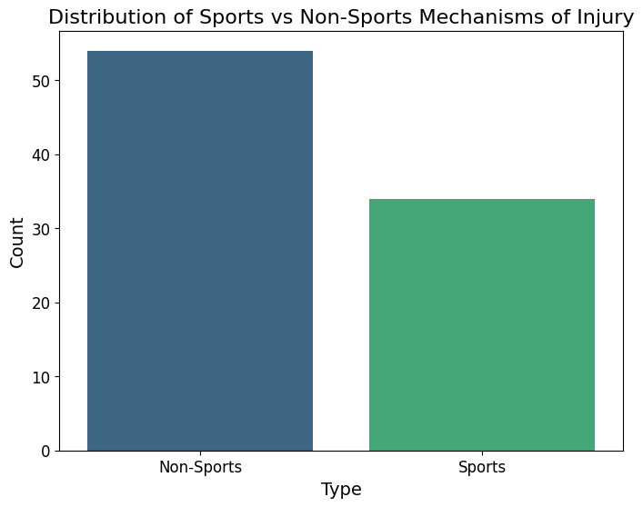

```python
# add 'type' column to distinguish sports and non sports activities
causes_results['type'] = 'Non-Sports'  # default to non sports

# assign 'sports' to categories related to sports
sports_categories = ['Soccer', 'Football', 'Basketball', 'Volleyball', 'Running'
                     'Crossfit', 'Dancing', 'Ultimate Frisbee', 'Baseball/Softball',
                     'MMA Training','Wrestling']

# update 'type' column for sports related categories
causes_results.loc[causes_results['category'].isin(sports_categories), 'type'] = 'Sports'

# count occurrences of each type
type_counts = causes_results['type'].value_counts()

# graph in bar chart form
plt.figure(figsize=(8, 6))
sns.barplot(x=type_counts.index, y=type_counts.values, palette='viridis')
plt.title('Distribution of Sports vs Non-Sports Mechanisms of Injury', fontsize=16)
plt.xlabel('Type', fontsize=14)
plt.ylabel('Count', fontsize=14)
plt.xticks(fontsize=12)
plt.yticks(fontsize=12)
plt.show()
```

Like above, we wanted to determine what proportion of each broad category of potential ACL tear ended up being confirmed.

```python
# group by type (sports vs non sports) to calculate counts and proportions
type_summary = causes_results.groupby('type').agg(
    Incident_Count=('Torn ACL from Arthroscopy', 'size'),
    Proportion_Torn_ACL=('Torn ACL from Arthroscopy', 'mean')
).reset_index()

# sort by Proportion_Torn_ACL to see which category is most associated with a torn ACL
type_summary = type_summary.sort_values(by='Proportion_Torn_ACL')
type_summary
```

|  | type | Incident_Count | Proportion_Torn_ACL |
| --- | --- | --- | --- |
| 0 | Non-Sports | 54 | 0.259259 |
| 1 | Sports | 34 | 0.705882 |

These results were graphed:

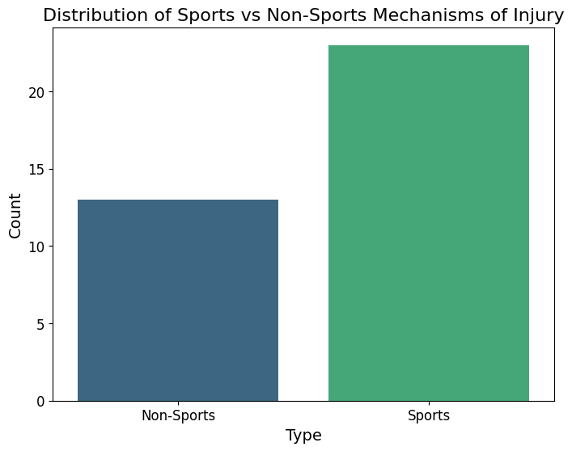

```python
# add 'type' column to distinguish sports and non sports activities
causes_results['type'] = 'Non-Sports'  # default to non sports

# assign 'sports' to categories related to sports
sports_categories = ['Soccer', 'Football', 'Basketball', 'Volleyball', 'Running'
                     'Crossfit', 'Dancing', 'Ultimate Frisbee', 'Baseball/Softball',
                     'MMA Training','Wrestling']

# update 'type' column for sports related categories
causes_results.loc[causes_results['category'].isin(sports_categories), 'type'] = 'Sports'

# count occurrences of each type
type_counts = causes_results['type'].value_counts()

y=type_counts.values
y[0] = y[0] *0.259259
y[1] = y[1] * 0.705882
y

# graph in bar chart form
plt.figure(figsize=(8, 6))
sns.barplot(x=type_counts.index, y=y, palette='viridis')
plt.title('Distribution of Sports vs Non-Sports Mechanisms of Injury', fontsize=16)
plt.xlabel('Type', fontsize=14)
plt.ylabel('Count', fontsize=14)
plt.xticks(fontsize=12)
plt.yticks(fontsize=12)
plt.show()
```

Finally, the two were added together on top of one another to visually show the difference in number of injuries were present on the knee for both non sports and sports related injuries, and how many were actually ACL tears.

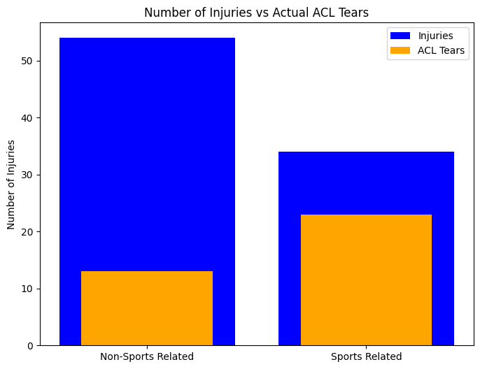

```python
# add 'type' column to distinguish sports and non sports activities
causes_results['type'] = 'Non-Sports'  # default to non sports

# assign 'sports' to categories related to sports
sports_categories = ['Soccer', 'Football', 'Basketball', 'Volleyball', 'Running'
                     'Crossfit', 'Dancing', 'Ultimate Frisbee', 'Baseball/Softball',
                     'MMA Training','Wrestling']

# update 'type' column for sports related categories
causes_results.loc[causes_results['category'].isin(sports_categories), 'type'] = 'Sports'

# count occurrences of each type
type_counts = causes_results['type'].value_counts()
categories = ['Non-Sports Related', 'Sports Related']
main_values = type_counts.values
fig, ax = plt.subplots(figsize=(8, 6))

# Plot main bars
bars = ax.bar(categories, main_values, color='blue', label='Injuries')
y = type_counts.values
#Correct numbers for actual values.
y[0] = y[0] *0.259259
y[1] = y[1] * 0.705882
# Data for additional bars in front of main bars
additional_values = y
additional_offsets = [0.2, -0.2]  # Offsets to place additional bars in front
# Plot additional bars in front of main bars
for i, bar in enumerate(bars):
    ax.bar(categories[i], additional_values[i], color='orange', width=0.6, label='ACL Tears' if i == 0 else "")

# Adding labels and title
ax.set_ylabel('Number of Injuries')
ax.set_title('Number of Injuries vs Actual ACL Tears')

# Display legend
ax.legend()

# Show the plot
plt.show()
```

From this information we can incorportate sports vs non sports into our model.

## Awareness Compared to Reality

Finally, moving on to awareness, we used ACL3, which was a questionaire assessing where and how people got information on ACL injuries. We were able to assess the percentage of people that believed certain factors were a cause for ACL tears. Percentages in the below graph exceed 100 because people were able to select more than one category.

```
   UserID  Bone Geometry  ACL Size  Joint Laxity  Hormone  Flexibility  \
1       1              1         1             1        0            1
2       0              1         1             1        0            1
3       3              0         1             1        0            1
4       4              1         1             0        0            1
5       5              1         1             0        0            1

   Foot Pronation  Weak Quadricep Muscle  Weak Hamstring Muscle  \
1               0                      1                      0
2               0                      1                      1
3               0                      1                      1
4               1                      1                      1
5               1                      1                      1

   Weak Hip Muscle  Balance  Weight  Drinking  Smoking  Genu Valgum  \
1                0        1       1         0        0            0
2                1        1       1         0        0            1
3                1        1       1         0        0            0
4                0        1       1         0        0            1
5                1        1       1         0        0            1

   Genu Varum  Sex  Age
1           0  NaN   34
2           1    F   49
3           1    F   49
4           1  NaN   53
5           1  NaN   52
```

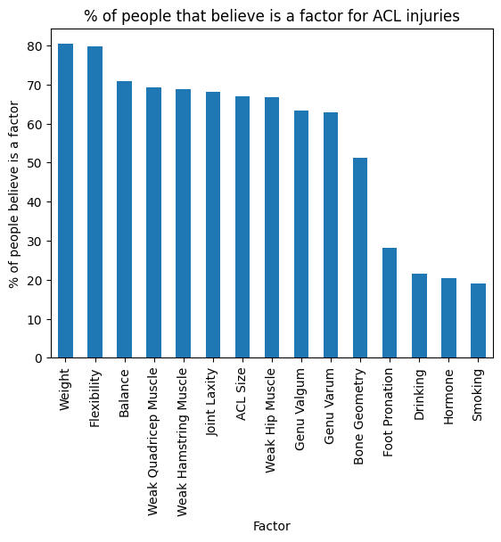

```python
#Taking all of the values from the second question and better formating it
ACL3_Fac = ACL3[["UserID","Bone Geometry","ACL Size","Joint Laxity",
                    "Hormone","Flexibility","Foot Pronation","Weak Quadricep Muscle",
                    "Weak Hamstring Muscle","Weak Hip Muscle","Balance","Weight",
                    "Drinking","Smoking","Genu Valgum","Genu Varum","Sex","Age"]]

#Fixing the 2 into false, like the previous values
#ACL3_Fac =ACL3_Fac.replace(1,1) Not needed code, but kept for if needed
ACL3_Fac =ACL3_Fac.replace(2,0)

#Prints dataset
print(ACL3_Fac.head(5))

#Takes percentage of each factor considered
factor_ave = ACL3_Fac[["Bone Geometry","ACL Size","Joint Laxity",
                    "Hormone","Flexibility","Foot Pronation","Weak Quadricep Muscle",
                    "Weak Hamstring Muscle","Weak Hip Muscle","Balance","Weight",
                    "Drinking","Smoking","Genu Valgum","Genu Varum"]].sum()/len(ACL3_Fac) *100

#Resorts the values highest to lowest
factor_ave = factor_ave.sort_values(ascending = False)

#Plotting the values
ax = factor_ave.plot.bar()
ax = plt.title("% of people that believe is a factor for ACL injuries")
ax = plt.ylabel("% of people believe is a factor")
ax = plt.xlabel("Factor")
```

However, to test this theory, we took the most important factor considered, weight, and used the ACL4 dataset to determine how accurate this was. To determine, this, we compared the weight of the players against the severity of their ACL injuries. If weight is a significant factor, then the higher the severity of the injury should related to the higher weight of a player.

To test this, we took every player from each severity and took the average weights of the players from these severities and graphed it below.

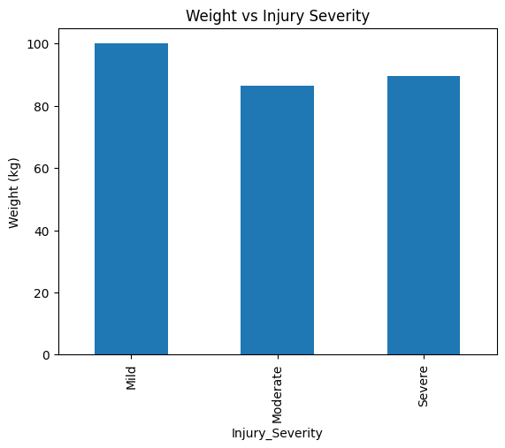

```python
ACL4.groupby(["Injury_Severity"])["Weight_kg"].mean().plot.bar(ylabel = "Weight (kg)", title = "Weight vs Injury Severity")
```

As can be seen, weight is actually slightly higher in the mild category, with the moderate and severe being quite similar. This shows that weight is not necessarily a signficant factor, based on the data. However, this could also be skewed by the lack of large number of players, allowing outliers to how more influence. Additionally, a lot of basketball players have a lot of similar builds, potentially causing the similarity in weights. Though, there are no significant differences in weight vs severity of the ACL tear observed.

## Injury Diagnosis

ACL tears can be diagnosed in three ways with arthroscopy being the gold standard (as stated in the ACL2 introduction). However, ACL2 also provided information on whether the Lachman test was postive, whether the doctor believed the patient had a torn ACL, and if the MRI showed a torn ACL. These factors were able to be compared to the gold standard test to determine their relative accuracies.

To read more about the different ACL tests and the fact that arthroscopy is the gold standard, see the paper *Diagnostic Accuracy of Non-invasive Tests Versus Arthroscopy in Anterior Cruciate Ligament (ACL) Injuries*

Link: https://pubmed.ncbi.nlm.nih.gov/38910689/

```python
# accuracy of diagnosis
diagnosis_df = ACL2[["Lachman injured",
                     "Diagnosis by Physician",
                     "ACL MRI",
                     'Torn ACL from Arthroscopy']]
# These are all the different ways the study attemped to diagnose an ACL tear
# with ACL arthroscopy being the last (actually surgical where you look and see
# if the ACL is torn). We can use this dataframe to compare the accuracy of
# Lachman tests, physician diagnoses, and ACL MRIs. Anthroscopy is the gold
# standard test.

diagnosis_df
```

|  | Lachman injured | Diagnosis by Physician | ACL MRI | Torn ACL from Arthroscopy |
| --- | --- | --- | --- | --- |
| 0 | 0.0 | 0.0 | 1.0 | 1.0 |
| 1 | 1.0 | 1.0 | 1.0 | 1.0 |
| 2 | 1.0 | 1.0 | 1.0 | 1.0 |
| 3 | 1.0 | 1.0 | 1.0 | 1.0 |
| 4 | 0.0 | 0.0 | 1.0 | 1.0 |
| ... | ... | ... | ... | ... |
| 83 | 0.0 | 0.0 | 0.0 | 0.0 |
| 84 | 0.0 | 0.0 | 0.0 | 0.0 |
| 85 | 0.0 | 0.0 | 0.0 | 0.0 |
| 86 | 0.0 | 0.0 | 0.0 | 0.0 |
| 87 | 0.0 | 0.0 | 0.0 | 0.0 |

88 rows × 4 columns

```python
# calculate accuracy for each method
accuracy = {}
for column in diagnosis_df.columns[:-1]:  # exclude 'Torn ACL from Arthroscopy' column
    correct_predictions = (diagnosis_df[column] == diagnosis_df["Torn ACL from Arthroscopy"]).sum()
    accuracy[column] = correct_predictions / len(diagnosis_df)

# create dataframe to display accuracies
accuracy_df = pd.DataFrame(list(accuracy.items()), columns=['Diagnostic Method', 'Accuracy'])
accuracy_df
```

|  | Diagnostic Method | Accuracy |
| --- | --- | --- |
| 0 | Lachman injured | 0.943182 |
| 1 | Diagnosis by Physician | 0.954545 |
| 2 | ACL MRI | 1.000000 |

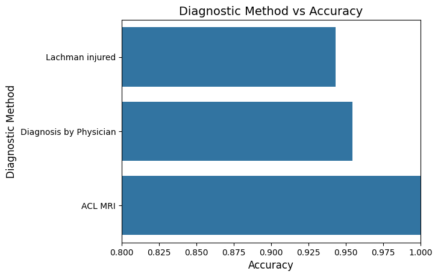

```python
# diagnostic methods vs accuracy
plt.figure()
sns.barplot(x='Accuracy', y='Diagnostic Method', data=accuracy_df)

# plot
plt.xlim(0.8, 1)
plt.title('Diagnostic Method vs Accuracy', fontsize=14)
plt.xlabel('Accuracy', fontsize=12)
plt.ylabel('Diagnostic Method', fontsize=12)
plt.show()
```

It turns out that in this case ACL MRIs were equally as accurate as ACL arthroscopy at diagnosing ACL tears. The Lachman test was the least likely by still had a relatively high accuracy at 94%. The Lachman test is also the easiest and requires the least equipment. For further reading and a video on a Lachman test being performed see this Physiopedia article: https://www.physio-pedia.com/Lachman_Test.

Since the Lachman test is an inexpensive, easy, and relatively accurate way to diagnose an ACL tear, this will be the factor of choice for our model.

## Demographic Factors

Finally to sort demographic factors to add to our model, we modified ACL2 (which was very long and had a lot of categories) to just contain demographic data such as age, sex, and whether or not the ACL was actually torn. To determine a positive or negative ACL tear we once again used the category 'Torn ACL from Arthroscopy'.

```python
# demographic dataframe
demo_ACL2_df = ACL2[['Age', 'sex', 'Torn ACL from Arthroscopy']]
demo_ACL2_df
```

|  | Age | sex | Torn ACL from Arthroscopy |
| --- | --- | --- | --- |
| 0 | 29.0 | F | 1.0 |
| 1 | 30.0 | M | 1.0 |
| 2 | 18.0 | M | 1.0 |
| 3 | 31.0 | M | 1.0 |
| 4 | 28.0 | F | 1.0 |
| ... | ... | ... | ... |
| 83 | 41.0 | F | 0.0 |
| 84 | 33.0 | M | 0.0 |
| 85 | 20.0 | F | 0.0 |
| 86 | 18.0 | M | 0.0 |
| 87 | 39.0 | F | 0.0 |

88 rows × 3 columns

From this data it is very easy to make a plot such as age vs positive ACL tear:

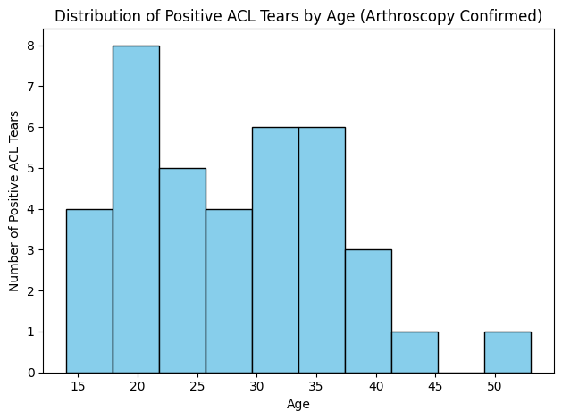

```python
# filter data to only include rows where 'Torn ACL from Arthroscopy' is 1 (confirmed tear)
positive_acl_data = demo_ACL2_df[demo_ACL2_df['Torn ACL from Arthroscopy'] == 1]

# plot histogram
plt.figure()
plt.hist(positive_acl_data['Age'], bins=10, color='skyblue', edgecolor='black')
plt.xlabel('Age')
plt.ylabel('Number of Positive ACL Tears')
plt.title('Distribution of Positive ACL Tears by Age (Arthroscopy Confirmed)')
plt.tight_layout()
plt.show()
```

The mean age of the entire dataset was calculated:

```python
ACL2['Age'].mean()
```

```
31.431818181818183
```

Then the mean age of the confirmed ACL tears were calculated:

```python
demo_ACL2_df[demo_ACL2_df['Torn ACL from Arthroscopy'] == 1]['Age'].mean()
```

```
27.710526315789473
```

The mean age was slightly lower so this could potentially be a factor and is worthy of further investigation.

We can also see the amount of males vs females who tore their ACL in this data.

```python
# count females with potentially torn ACLs
female_acl_count = ACL2[ACL2["sex"] == 'F'].shape[0]

# count males with potentially torn ACLs
male_acl_count = ACL2[ACL2["sex"] == 'M'].shape[0]

# print in a pretty way
print(f"Females with potential torn ACLs: {female_acl_count}")
print(f"Males with potential torn ACLs: {male_acl_count}")
```

```
Females with potential torn ACLs: 39
Males with potential torn ACLs: 49
```

```python
# filter for confirmed ACL tears
positive_acl_data = demo_ACL2_df[demo_ACL2_df['Torn ACL from Arthroscopy'] == 1]

# count females with confirmed torn ACLs
female_acl_count_comfirm = positive_acl_data[positive_acl_data["sex"] == 'F'].shape[0]

# count males with confirmed torn ACLs
male_acl_count_confirm = positive_acl_data[positive_acl_data["sex"] == 'M'].shape[0]

# print in a pretty way
print(f"Females with confirmed torn ACLs: {female_acl_count_comfirm}")
print(f"Males with confirmed torn ACLs: {male_acl_count_confirm}")
```

```
Females with confirmed torn ACLs: 18
Males with confirmed torn ACLs: 20
```

The proportions were then calculated:

```python
print(f"Females ACL fraction confirmed: {female_acl_count_comfirm / female_acl_count}")
print(f"Males ACL fraction confirmed: {male_acl_count_confirm / male_acl_count}")
```

```
Females ACL fraction confirmed: 0.46153846153846156
Males ACL fraction confirmed: 0.40816326530612246
```

Interestingly, females have the higher proportion although the sample size is small. This is consistent with Yale's research on gender and ACL injuries.

Link for further reading: https://www.yalemedicine.org/news/sports-injuries-gender

Next we were able to use another dataset relating to basketball players, their demographics, and their injuries as well as rehabilitation statistics to find statistics about height and weight.

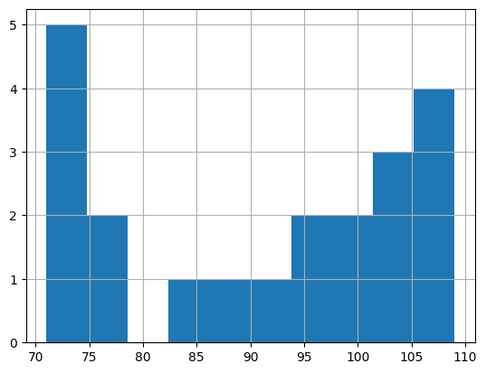

```python
ACL4["Weight_kg"].hist()
```

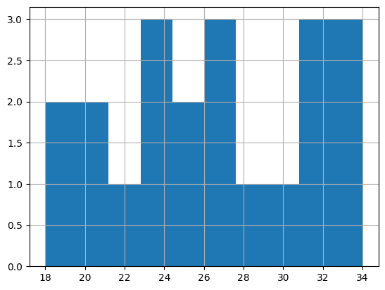

```python
ACL4["Age"].hist()
```

# Analysis and Hypothesis Testing (Models)

## K-Nearest Neighbors Models

We decided we wanted to make a k-nearest neighbors model based on sports vs non sports, sex, age, and what the Lachman injury diagnosis was. The goal of this model was to better predict noninvasively whether a potential ACL tear would be confirmed by ACL arthroscopy.

First, we created a new dataframe with the information we needed:

```python
# select columns from ACL2 and causes_results dataframes
selected_columns_cr = causes_results[['type']]  # from causes_results
selected_columns_acl2 = ACL2[['Lachman injured', 'Age', 'sex','Torn ACL from Arthroscopy']]  # from ACL2

# concatenate columns horizontally
knn_df = pd.concat([selected_columns_cr, selected_columns_acl2], axis=1)
knn_df
```

|  | type | Lachman injured | Age | sex | Torn ACL from Arthroscopy |
| --- | --- | --- | --- | --- | --- |
| 0 | Non-Sports | 0.0 | 29.0 | F | 1.0 |
| 1 | Sports | 1.0 | 30.0 | M | 1.0 |
| 2 | Non-Sports | 1.0 | 18.0 | M | 1.0 |
| 3 | Sports | 1.0 | 31.0 | M | 1.0 |
| 4 | Sports | 0.0 | 28.0 | F | 1.0 |
| ... | ... | ... | ... | ... | ... |
| 83 | Non-Sports | 0.0 | 41.0 | F | 0.0 |
| 84 | Non-Sports | 0.0 | 33.0 | M | 0.0 |
| 85 | Non-Sports | 0.0 | 20.0 | F | 0.0 |
| 86 | Non-Sports | 0.0 | 18.0 | M | 0.0 |
| 87 | Non-Sports | 0.0 | 39.0 | F | 0.0 |

88 rows × 5 columns

To perform the KNN classification, we first one hot end encoded the columns 'sex' and 'type' because they were originally categorical. Next we added them to the original dataframe and selected our features of interest. In this case this was age, sex, lachman result, and type of injury (sport vs non sport related). To make a better model we chose to use a k cross fold validation and we used 5 cross folds.

```python
pd.get_dummies(knn_df).head()
```

|  | Lachman injured | Age | Torn ACL from Arthroscopy | type_Non-Sports | type_Sports | sex_F | sex_M |
| --- | --- | --- | --- | --- | --- | --- | --- |
| 0 | 0.0 | 29.0 | 1.0 | True | False | True | False |
| 1 | 1.0 | 30.0 | 1.0 | False | True | False | True |
| 2 | 1.0 | 18.0 | 1.0 | True | False | False | True |
| 3 | 1.0 | 31.0 | 1.0 | False | True | False | True |
| 4 | 0.0 | 28.0 | 1.0 | False | True | True | False |

```python
# one hot encoded columns for 'sex' and 'type' without dropping original columns
sex_encoded = pd.get_dummies(knn_df['sex'], prefix='sex')
type_encoded = pd.get_dummies(knn_df['type'], prefix='type')

# concatenate one hot encoded columns with original dataframe
knn_df = pd.concat([knn_df, sex_encoded, type_encoded], axis=1)

# select features (X) and target (y) (exclude original 'sex' and 'type')
X = knn_df[['Lachman injured', 'Age'] + list(sex_encoded.columns) + list(type_encoded.columns)]  # features
y = knn_df['Torn ACL from Arthroscopy']  # target

# initialize knn classifier
knn_model = KNeighborsClassifier(n_neighbors=3)

# k fold cross validation
cv_scores = cross_val_score(knn_model, X, y, cv=5)
print(f'Accuracy: {np.mean(cv_scores):.4f}')
```

```
Accuracy: 0.6072
```

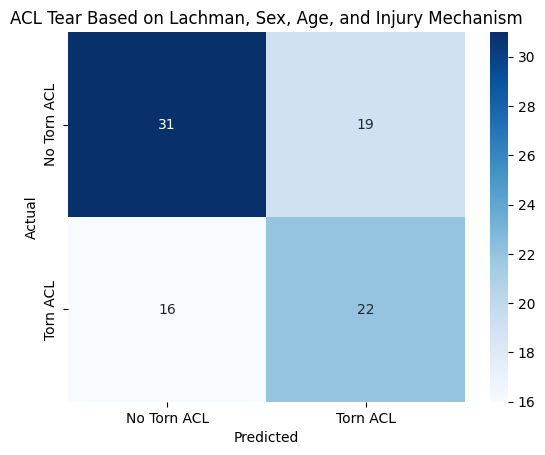

```python
# perform cross validation and get predictions
y_pred = cross_val_predict(knn_model, X, y, cv=5)

# compute confusion matrix
cm = confusion_matrix(y, y_pred)

# plot confusion matrix using heatmap
sns.heatmap(cm, annot=True, fmt='d', cmap='Blues', xticklabels=['No Torn ACL', 'Torn ACL'], yticklabels=['No Torn ACL', 'Torn ACL'])
plt.xlabel('Predicted')
plt.ylabel('Actual')
plt.title('ACL Tear Based on Lachman, Sex, Age, and Injury Mechanism')
plt.show()
```

To attempt a new model, we removed age even though it seemed logical that it would be a factor.

```python
# one hot encoded columns for 'sex' and 'type' without dropping original columns
sex_encoded = pd.get_dummies(knn_df['sex'], prefix='sex')
type_encoded = pd.get_dummies(knn_df['type'], prefix='type')

# concatenate one hot encoded columns with original dataframe
knn_df = pd.concat([knn_df, sex_encoded, type_encoded], axis=1)

# select features (X) and target (y) (exclude original 'sex' and 'type')
X = knn_df[['Lachman injured'] + list(sex_encoded.columns) + list(type_encoded.columns)]  # features
y = knn_df['Torn ACL from Arthroscopy']  # target variable

# initialize knn classifier
knn_model = KNeighborsClassifier(n_neighbors=3)

# k fold cross validation
cv_scores = cross_val_score(knn_model, X, y, cv=5)
print(f'Accuracy: {np.mean(cv_scores):.4f}')
```

```
Accuracy: 0.7928
```

This model was much more accurate so it seems that age was misleading. We again created a confusion matrix to visualize the results.

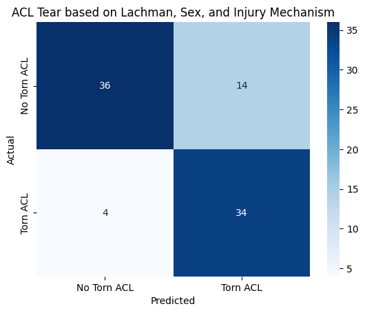

```python
# perform cross validation and get predictions
y_pred = cross_val_predict(knn_model, X, y, cv=5)

# compute confusion matrix
cm = confusion_matrix(y, y_pred)

# plot confusion matrix using heatmap
sns.heatmap(cm, annot=True, fmt='d', cmap='Blues', xticklabels=['No Torn ACL', 'Torn ACL'], yticklabels=['No Torn ACL', 'Torn ACL'])
plt.xlabel('Predicted')
plt.ylabel('Actual')
plt.title('ACL Tear based on Lachman, Sex, and Injury Mechanism')
plt.show()
```

Finally, we just made a KNN model based on the Lachman diagnosis and type of injury (sport vs non sport) and visualized the results.

```python
# one hot encoded columns for 'sex' and 'type' without dropping original columns
type_encoded = pd.get_dummies(knn_df['type'], prefix='type')

# concatenate one hot encoded columns with original dataframe
knn_df = pd.concat([knn_df, sex_encoded, type_encoded], axis=1)

# select features (X) and target (y) (exclude original 'sex' and 'type')
X = knn_df[['Lachman injured'] + list(type_encoded.columns)]  # features
y = knn_df['Torn ACL from Arthroscopy']  # target variable

# initialize knn classifier
knn_model = KNeighborsClassifier(n_neighbors=3)

# k fold cross validation
cv_scores = cross_val_score(knn_model, X, y, cv=5)
print(f'Accuracy: {np.mean(cv_scores):.4f}')
```

```
Accuracy: 0.8654
```

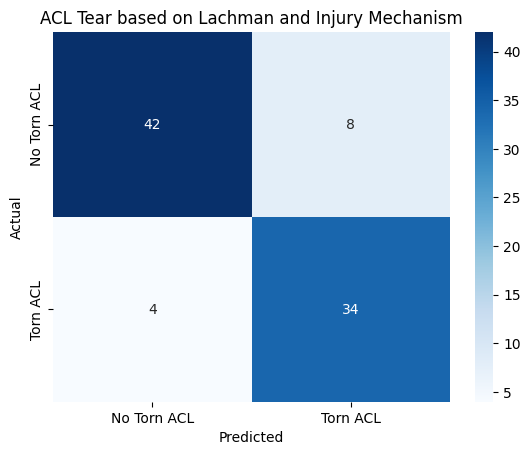

```python
# perform cross validation and get predictions
y_pred = cross_val_predict(knn_model, X, y, cv=5)

# compute confusion matrix
cm = confusion_matrix(y, y_pred)

# plot confusion matrix using heatmap
sns.heatmap(cm, annot=True, fmt='d', cmap='Blues', xticklabels=['No Torn ACL', 'Torn ACL'], yticklabels=['No Torn ACL', 'Torn ACL'])
plt.xlabel('Predicted')
plt.ylabel('Actual')
plt.title('ACL Tear based on Lachman and Injury Mechanism')
plt.show()
```

This model was even more accurate which is likely because both Lachman and injury type are fairly good predictors on their own.

This finally led us to make an overall correlation matrix that compared the correlation of the anthroscopy test to sex, type of injury, and the lachman test all into one for easier visuals.

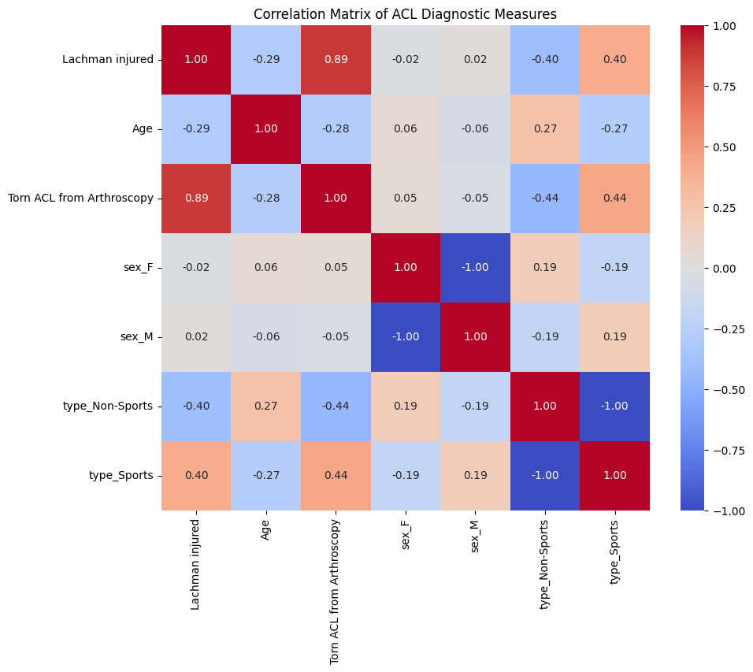

```python
# re-encode categorical columns
sex_encoded_full = pd.get_dummies(knn_df['sex'], prefix='sex', drop_first=False)
type_encoded_full = pd.get_dummies(knn_df['type'], prefix='type', drop_first=False)

# create dataframe specifically for correlation matrix
knn_df_for_corr = pd.concat([
    knn_df[['Lachman injured', 'Age', 'Torn ACL from Arthroscopy']],  # numeric and target columns
    sex_encoded_full,  # one-hot encoding sex
    type_encoded_full  # one-hot encoding type
], axis=1)

# correlation matrix
correlation_matrix = knn_df_for_corr.corr()

# show correlation matrix
plt.figure(figsize=(10, 8))
sns.heatmap(correlation_matrix, annot=True, cmap='coolwarm', fmt='.2f', cbar=True)
plt.title('Correlation Matrix of ACL Diagnostic Measures')
plt.show()
```

As can be seen with the torn ACL from Arthroscopy row, the only correlating factors are the lachman injured and the sports related injury. Though the sports related is not significant enough to determine if it is an ACL tear. This also shows how accurate the lachman test is overall, without being invasive as the arthroscopy test.

# Insight

## Awareness Compared to Reality Addendum (Less Significant EDA)

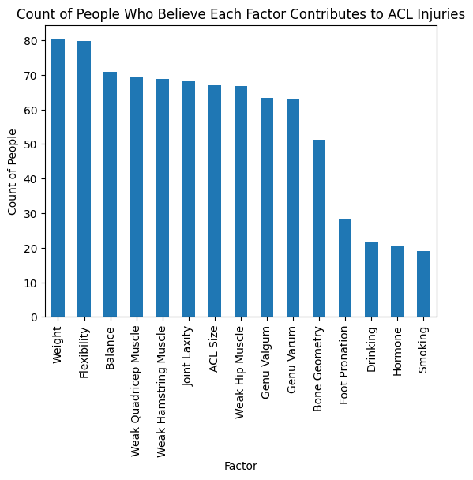

```python
# re sort values highest to lowest
factor_ave = factor_ave.sort_values(ascending=False)

# plot values
ax = factor_ave.plot.bar()
ax = plt.title("Count of People Who Believe Each Factor Contributes to ACL Injuries")
ax = plt.ylabel("Count of People")
ax = plt.xlabel("Factor")
plt.show()
```

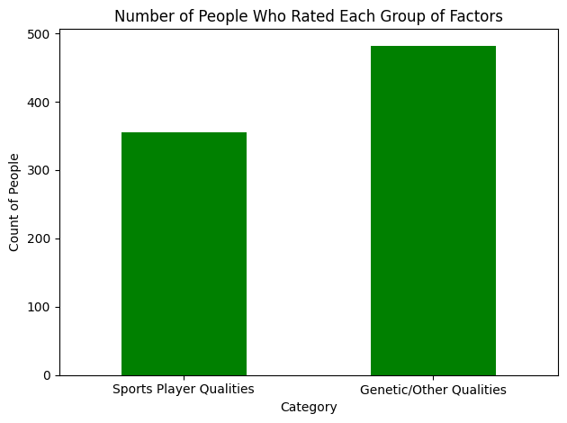

```python
# Define the categories
sports_player_qualities = [
    "Flexibility", "Weak Quadricep Muscle",
    "Weak Hamstring Muscle", "Weak Hip Muscle", "Balance"
]
genetic_other_qualities = [
    "Bone Geometry", "ACL Size", "Joint Laxity", "Hormone",
    "Drinking", "Smoking", "Genu Valgum", "Genu Varum","Foot Pronation","Weight"
    ]

# Select only numeric columns from ACL3_Fac
numeric_factors = sports_player_qualities + genetic_other_qualities
factor_counts = ACL3_Fac[numeric_factors].sum()

# Calculate total counts for each category
grouped_counts = {
    "Sports Player Qualities": factor_ave[sports_player_qualities].sum(),
    "Genetic/Other Qualities": factor_ave[genetic_other_qualities].sum(),
}

# Convert to a DataFrame for easier plotting
grouped_counts_df = pd.DataFrame.from_dict(grouped_counts, orient='index', columns=["Count"])

# Plot the grouped counts
ax = grouped_counts_df.plot.bar(legend=False, color=["green","blue"])
ax.set_title("Number of People Who Rated Each Group of Factors")
ax.set_ylabel("Count of People")
ax.set_xlabel("Category")
plt.xticks(rotation=0)
plt.tight_layout()
plt.show()
```

```python
sports_proportion = factor_ave[sports_player_qualities].sum() / (factor_ave[sports_player_qualities].sum() + factor_ave[genetic_other_qualities].sum())
genetic_proportion = factor_ave[genetic_other_qualities].sum() / (factor_ave[sports_player_qualities].sum() + factor_ave[genetic_other_qualities].sum())
print(f"Sports Factors Proportion: {sports_proportion}")
print(f"Non Sports Factors Proportion: {genetic_proportion}")
```

```
Sports Factors Proportion: 0.42417407456547696
Non Sports Factors Proportion: 0.575825925434523
```

To interpret these results we can think back to the mechanism of injury analysis earlier. The fact that 'No Inciting Event' didn't result in any ACL tears and the postive correlation between sports and ACL injuries seems to provide evidence against factors like weak hamstings and quadriceps being large factors in ACL tears. Sports players tend to have strong leg muscles and if those were a significant factor athletes would likely not be getting them at such a high rate. Additionally, sports players also tend to be balanced and flexible and again, those are the highest proportion of ACL tears. It seems like the public perception is inaccurate in this case although, as stated previously, we are limited by the size of our datasets.

## Conclusion

The central questions that we aimed to investigate with this analysis were:

1. What are the factors that affect a person's likelihood to tear their ACL?
2. How can ACL tears be diagnosed the easiest?

These two questions are very related and often the analysis was able to provide insight into both of them. We also wanted to undestand factors that could reasonably be perceived as related to ACL tears but actually were not correlated.

As stated many times before, there was not large volumes of ACL data readily available so these correlations were based off of a very small sample size. However, it should be a good example of how data can be collected, processed, visualized, and modeled.

```python
%%shell
# mv 'ACL Project' 'ACL Project.ipynb'
jupyter nbconvert 'ACL Project' --to html
```

```
[NbConvertApp] Converting notebook ACL Project.ipynb to html
[NbConvertApp] WARNING | Alternative text is missing on 16 image(s).
[NbConvertApp] Writing 1217964 bytes to ACL Project.html
```